# metabolomics analysis for mSphere, Carey et al. 2017

Maureen A Carey

updated Sept 18th, 2017

Set working directory and run helper function (to load libraries and functions) (warnings off here for package loading)

```r
# R version 3.2.4 (2016-03-10)
base_directory = '/Users/Mo/Desktop/lab/metabolomics/metabolomics_2017_submit'
setwd(base_directory)
source("helper_functions_met_methods.R",local = T)
```

Open datafile

```r
raw_file = read.csv("met_methods_raw_data.txt", sep = "\t", header = T,
                colClasses = c(rep(NA, 14), rep('numeric',35)),
                na.strings=c('',"NA"), stringsAsFactors = F)

raw_backup = raw_file

# comparison 1 for figure 2 and 3
fig2B = raw_file[1:375,-c(15:19,30:34,40:44)]
raw_file_comp1 = raw_file[,-c(15:19,30:34,40:44)] # select specified samples
raw_file_comp1 = raw_file_comp1[,-c(1,3:14)] # remove extra metabolite identifiers
raw_file_comp1 = raw_file_comp1[1:375,] # remove last empty row

# comparison 2 for figure 4
raw_file_comp2 = raw_file[,-c(15:29)] # select specified samples
raw_file_comp2 = raw_file_comp2[,-c(1,3:14)] # remove extra metabolite identifiers
raw_file_comp2 = raw_file_comp2[1:375,] # remove last empty row

rm(raw_file)
```

Count mets detected and generate Fig 2B

```r
raw = raw_file_comp1
#in all
dim(na.omit(raw))
```

```
## [1] 146  21
```

```r
# G2 = metabolites detected in every G2
G2 = raw[,1:11]; rownames(G2) = G2$BIOCHEMICAL; G2_all = na.omit(G2)
# G1_plus = metabolites detected in every G1 sample (G1 from comparison 1 and all from comparison 2)
G1 = raw[,c(1,12:21)]; rownames(G1) = G1$BIOCHEMICAL; G1_all = na.omit(G1)

find_uni = merge(G2_all,G1_all, by = "row.names", all = T)
# dim(find_uni[is.na(find_uni$BIOCHEMICAL.y),]) # found in all G2, not all G1
# dim(find_uni[is.na(find_uni$BIOCHEMICAL.x),]) # found in all G1, not all G2

# range of metabolites found in each replicate
for (i in 2:ncol(G2)) {
  print(length(na.omit(G2[,i]))) }
```

```
## [1] 267
## [1] 368
## [1] 355
## [1] 361
## [1] 334
## [1] 339
## [1] 358
## [1] 352
## [1] 319
## [1] 360
```

```r
for (i in 2:ncol(G1)) {
  print(length(na.omit(G1[,i]))) }
```

```
## [1] 230
## [1] 216
## [1] 225
## [1] 211
## [1] 239
## [1] 182
## [1] 207
## [1] 242
## [1] 212
## [1] 223
```

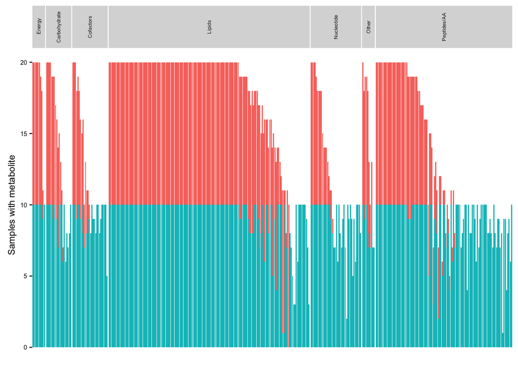

```r
rm(raw, i,find_uni,G2,G2_all,G1,G1_all)

fig2B = fig2B[,-c(1,5:14)]
m = melt(fig2B, id.vars = c("BIOCHEMICAL", "SUPER_PATHWAY", "SUB_PATHWAY"))
m2 = mutate(m, group = ifelse(substr(variable,0,1) == 'C', 'group2','group1'),
            val2 = ifelse(!is.na(value),1,0))
m2$SUPER_PATHWAY = ifelse(m2$SUPER_PATHWAY == 'Xenobiotics','Other',m2$SUPER_PATHWAY)
m2$SUPER_PATHWAY = ifelse(m2$SUPER_PATHWAY == 'Energy',' Energy',m2$SUPER_PATHWAY)
m2$SUPER_PATHWAY = ifelse(m2$SUPER_PATHWAY == 'Lipid','Lipids',m2$SUPER_PATHWAY)
m2$SUPER_PATHWAY = ifelse(m2$SUPER_PATHWAY == 'Carbohydrates','  Carbohydrates',m2$SUPER_PATHWAY)
m2$SUPER_PATHWAY = ifelse(m2$SUPER_PATHWAY == 'Amino Acid','Peptides/AA',m2$SUPER_PATHWAY)
m2$SUPER_PATHWAY = ifelse(m2$SUPER_PATHWAY == 'Peptide','Peptides/AA',m2$SUPER_PATHWAY)
m2$SUPER_PATHWAY = ifelse(m2$SUPER_PATHWAY == 'Cofactors and Vitamins','Cofactors',m2$SUPER_PATHWAY)

m3 = m2 %>% group_by(group,BIOCHEMICAL, SUPER_PATHWAY) %>%
  summarise(cn = sum(val2)) %>% arrange(cn)
m3$BIOCHEMICAL = factor(m3$BIOCHEMICAL, levels = rev(unique(m3$BIOCHEMICAL[order(m3$cn)])), ordered=TRUE)

dist = ggplot(data = m3, aes(x = factor(BIOCHEMICAL), fill = group)) +
  geom_bar(aes(y = cn),stat = "identity",position= "stack") +
  facet_grid(~SUPER_PATHWAY, scales = "free_x", space = "free_x") +
  xlab(NULL) + guides(fill = F) + custom_theme_dist +
  theme(axis.text.x = element_blank(), axis.ticks.x = element_blank(),
        strip.text = element_text(size = 5, angle = 90)) + ylab('Samples with metabolite')
dist
```

```r
setwd(paste(base_directory,'/figures',sep=""))
ggsave('fig_2b_aug2017.pdf', dist, width = 103, height = 50, units = "mm")

rm(dist, m, m2,m3,fig2B)
```

Plot parasite/DNA/Protein for Fig 2C

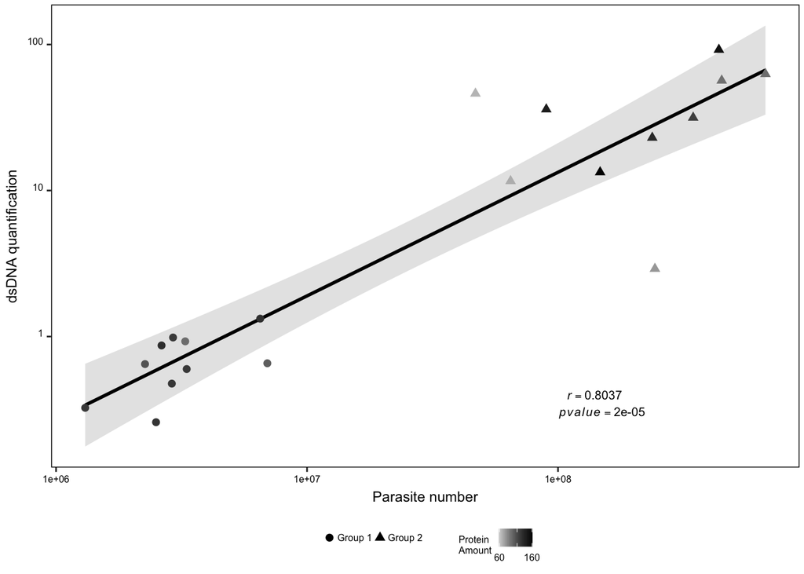

```r
raw1 = prep_raw(raw_file_comp1)
identifiers = prep_sample_identifiers(raw1)

# process sample data for plotting
df = identifiers[c(3,5,6,8,9),] # keep only protein, dna, parasite measures and IDS
df = as.data.frame(t(df)) # transpose
rownames(df) = df$CLIENT_IDENTIFIER; df$CLIENT_IDENTIFIER = NULL
indx = sapply(df, is.factor); df[indx] = lapply(df[indx], function(x) as.character(x))
df$CLIENT_PROTEIN = as.numeric(df$CLIENT_PROTEIN); df$DSDNA_ASSAY = as.numeric(df$DSDNA_ASSAY)
df$TOTAL_PARASITES = as.numeric(df$TOTAL_PARASITES)

for (i in 1:nrow(df)) { # re-name samples for ease
  if (strcmp("Res1_LowD1", df$GROUP_ID[i])) { df$GROUP_ID[i] = "Group 2"}
  else if (strcmp("Res1_HighD1", df$GROUP_ID[i])) { df$GROUP_ID[i] = "Group 2"}
  else if (strcmp("Res1_Exp", df$GROUP_ID[i])) { df$GROUP_ID[i] = "Group 1"}
  else { df$GROUP_ID[i] = "Group 1"} } #if (strcmp("Res2_Exp", df$GROUP_ID[i]))

corr_eqn_r <- function(x,y, digits = 4) { corr_coef = round(cor(x, y), digits = digits)
  paste("italic(r) == ", corr_coef) }
corr_eqn_p <- function(x,y, digits = 6) { p_value = round(cor.test(x,y)$p.value, digits = digits)
  paste("italic(pvalue) == ", format(p_value, scientific=FALSE)) }

# plot parasite #, dna amount, and protein amount NOTE LOG10 AXIS
summary = ggplot(df, aes(x = TOTAL_PARASITES, y = DSDNA_ASSAY )) +
  custom_theme_pca + theme( plot.margin = unit(c(1,1,1,1),"mm"),
                        legend.title=element_text(size = 6),
                        legend.text=element_text(size = 6),
                        legend.key = element_rect(fill = NA),
                        legend.key.height = unit(4, "mm"),
                        legend.key.width = unit(1.5, "mm"),
                        legend.position = "bottom",
                        legend.direction = "horizontal") +
  geom_smooth(colour = "black", fill = "gray", method = "lm") +
  geom_point(size=2, aes(color = as.numeric(CLIENT_PROTEIN), shape = GROUP_ID)) +
  scale_colour_gradient("Protein \nAmount", low="lightgrey", high="black",
                        breaks = c(50,110,161), limits = c(50,161),
                        labels=c("60","","160")) +
  scale_shape(NULL) + scale_y_log10() + scale_x_log10() +
  xlab("Parasite number") + ylab("dsDNA quantification") +
  annotate("text", label = corr_eqn_r(df$TOTAL_PARASITES,df$DSDNA_ASSAY),
           x = 140000000, y = .4, size = 2.7, colour = "black", parse = T) +
  annotate("text", label = corr_eqn_p(df$TOTAL_PARASITES,df$DSDNA_ASSAY),
           x = 150000000, y = .3, size = 2.7, colour = "black", parse = T)
summary
```

```r
s = summary + guides(shape = F, color = F)

setwd(paste(base_directory,'/figures',sep=""))
ggsave('fig_2c_sample_characteristics_aug2017.png', s,
       width = 65, height = 100, units = "mm")
```

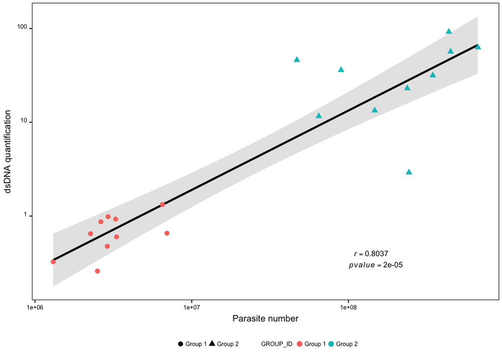

```r
summary = ggplot(df, aes(x = TOTAL_PARASITES, y = DSDNA_ASSAY)) +
  custom_theme_pca + theme( plot.margin = unit(c(1,1,1,1),"mm"),
                            legend.title=element_text(size = 6),
                            legend.text=element_text(size = 6),
                            legend.key = element_rect(fill = NA),
                            legend.key.height = unit(4, "mm"),
                            legend.key.width = unit(1.5, "mm"),
                            legend.position = "bottom",
                            legend.direction = "horizontal") +
  geom_smooth(colour = "black", fill = "gray", method = "lm") +
  geom_point(size=2, aes(color = GROUP_ID, shape = GROUP_ID)) +
  scale_shape(NULL) + scale_y_log10() + scale_x_log10() +
  xlab("Parasite number") + ylab("dsDNA quantification") +
  annotate("text", label = corr_eqn_r(df$TOTAL_PARASITES,df$DSDNA_ASSAY),
           x = 140000000, y = .4, size = 2.7, colour = "black", parse = T) +
  annotate("text", label = corr_eqn_p(df$TOTAL_PARASITES,df$DSDNA_ASSAY),
           x = 150000000, y = .3, size = 2.7, colour = "black", parse = T)
summary
```

```r
s = summary + guides(shape = F, color = F)

setwd(paste(base_directory,'/figures',sep=""))
ggsave('audrey_sample_characteristics_sept2017.pdf', s,
       width = 65, height = 100, units = "mm")
```

```r
group1 = df[df$GROUP_ID == 'Group 1',]; group2 = df[df$GROUP_ID == 'Group 2',]

# print correlation scores for other comparisons
corr_eqn_r2 <- function(x,y) { corr_coef = round(cor(x, y), digits = 4)}
corr_eqn_p2 <- function(x,y) { p_value = round(cor.test(x,y)$p.value, digits = 4)}

print('correlation between parasite and protein in all samples (r,p)')
print(corr_eqn_r2(df$TOTAL_PARASITES,df$CLIENT_PROTEIN))
print(corr_eqn_p2(df$TOTAL_PARASITES,df$CLIENT_PROTEIN))
print('correlation between dna and protein in all samples (r,p)')
print(corr_eqn_r2(df$DSDNA_ASSAY,df$CLIENT_PROTEIN))
print(corr_eqn_p2(df$DSDNA_ASSAY,df$CLIENT_PROTEIN))
# NO CORRELATION BETWEEN PROTEIN AND ANYTHING

print('GROUP 1 correlation between parasite and protein (r,p)')
print(corr_eqn_r2(group1$TOTAL_PARASITES,group1$CLIENT_PROTEIN))
print(corr_eqn_p2(group1$TOTAL_PARASITES,group1$CLIENT_PROTEIN))
print('GROUP 1 correlation between dna and protein (r,p)')
print(corr_eqn_r2(group1$DSDNA_ASSAY,group1$CLIENT_PROTEIN))
print(corr_eqn_p2(group1$DSDNA_ASSAY,group1$CLIENT_PROTEIN))
# NO CORRELATION BETWEEN PROTEIN AND ANYTHING IN GROUP1

print('GROUP 2 correlation between parasite and  protein (r,p)')
print(corr_eqn_r2(group2$TOTAL_PARASITES,group2$CLIENT_PROTEIN))
print(corr_eqn_p2(group2$TOTAL_PARASITES,group2$CLIENT_PROTEIN))
print('GROUP 2 correlation between dna and  protein (r,p)')
print(corr_eqn_r2(group2$DSDNA_ASSAY,group2$CLIENT_PROTEIN))
print(corr_eqn_p2(group2$DSDNA_ASSAY,group2$CLIENT_PROTEIN))
# NO CORRELATION BETWEEN PROTEIN AND ANYTHING IN GROUP2

rm(i, indx, summary, group1, group2, raw1, identifiers, corr_eqn_p, corr_eqn_r,df,corr_eqn_p2,corr_eqn_r2)
```

```
## [1] "correlation between parasite and protein in all samples (r,p)"
## [1] -0.0411
## [1] 0.8634
## [1] "correlation between dna and protein in all samples (r,p)"
## [1] 0.041
## [1] 0.8636
## [1] "GROUP 1 correlation between parasite and protein (r,p)"
## [1] -0.2157
## [1] 0.5496
## [1] "GROUP 1 correlation between dna and protein (r,p)"
## [1] -0.0396
## [1] 0.9136
## [1] "GROUP 2 correlation between parasite and  protein (r,p)"
## [1] 0.0887
## [1] 0.8076
## [1] "GROUP 2 correlation between dna and  protein (r,p)"
## [1] 0.2131
## [1] 0.5545
```

Check to see if median and SD scale (Bias requires log transformation)

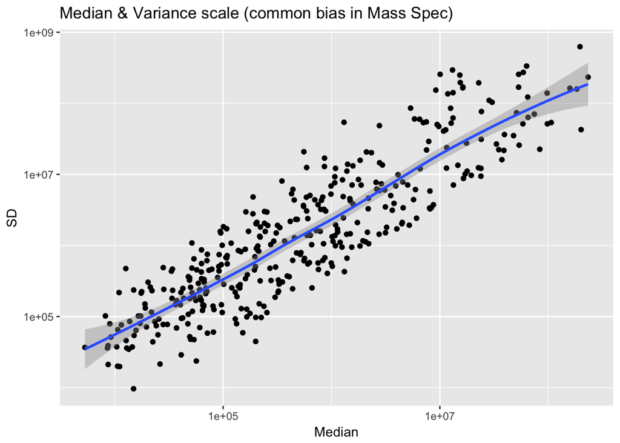

```r
raw1 = prep_raw(raw_file_comp1)
identifiers = prep_sample_identifiers(raw1)
raw2 = remove_NAs(raw1)
raw3 = as.matrix(imputing_missing(raw2,0))

# scale to median (so all metabolite abundances hover around 1)
df = as.data.frame(raw3); df$mets = rownames(df)
df = mutate(df, med = apply(df[,-c(21)],1,median), stand_dev = apply(df[,-c(21)],1,sd))
df2 = df[,c(21:23)] # keep just median and SD

df2= df2[order(df2$med,df2$stand_dev),]
ggplot(data = df2, aes(x = med, y = stand_dev)) + geom_point() +
  scale_x_log10() + scale_y_log10() + geom_smooth(method = 'loess') +
  xlab('Median') + ylab('SD') + ggtitle("Median & Variance scale (common bias in Mass Spec)")
```

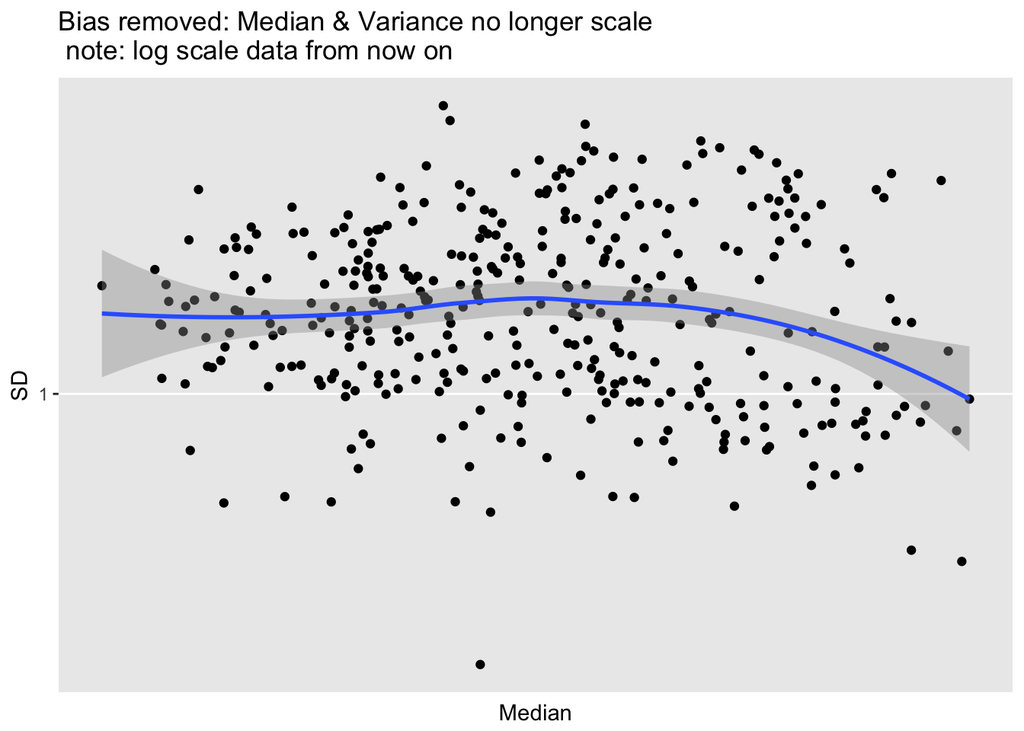

```r
# repeat with logged data
df = as.data.frame(log2(raw3));df$mets = rownames(df)
df = mutate(df, log_med = apply(df[,-c(21)],1,median), log_stand_dev = apply(df[,-c(21)],1,sd))
df2 = df[,c(21:23)] # keep just median and SD

df2= df2[order((df2$log_med),(df2$log_stand_dev)),]
ggplot(data = df2, aes(x = log_med, y = log_stand_dev)) + geom_point() +
  scale_x_log10() + scale_y_log10() + geom_smooth(method = 'loess') +
  xlab('Median') + ylab('SD') +
  ggtitle("Bias removed: Median & Variance no longer scale\n note: log scale data from now on")
```

```r
rm(df,df2, raw1, raw2, raw3)
```

Notes to self: Check Aug1 file for history of changes Aug 9 has correlation plots and exploration of median v mean centering, removal of outliers

Preprocess data (Comparison 1)

```r
raw1 = prep_raw(raw_file_comp1) # adjust formating
identifiers = prep_sample_identifiers(raw1) # extract relevant samples
raw_remove_NAs = remove_NAs(raw1) # check no nondetected metabolites due to subset
no_missing_data = imputing_missing(raw_remove_NAs, 0) #imput missing values

labels1 = c("S1","S1","S1","S1","S1","S1","S1","S1","S1","S1",
            "S2","S2","S2","S2","S2","S2","S2","S2","S2","S2")

# Sample normalization
norm_dna = normalize(no_missing_data,identifiers,"dna") # DNA NORMALIZATION
norm_pro = normalize(no_missing_data,identifiers,"protein") # PROTEIN NORMALIZATION
norm_para = normalize(no_missing_data,identifiers,"para") # PARASITE NUMBER NORMALIZATION

# Feature normalization (log, center, scale)
# log
log_nonorm = log2(no_missing_data)
log_dna = log2(norm_dna)
log_pro = log2(norm_pro)
log_para = log2(norm_para)
# prep format for PCA
data_transposed_unnorm = t(log_nonorm)
data_transposed_dna = t(log_dna)
data_transposed_pro = t(log_pro)
data_transposed_para = t(log_para)
# [median] center & [sd] scale
data_for_pca_unnorm = median_center_scale_data(data_transposed_unnorm)
data_for_pca_dna = median_center_scale_data(data_transposed_dna)
data_for_pca_pro = median_center_scale_data(data_transposed_pro)
data_for_pca_para = median_center_scale_data(data_transposed_para)

rm(raw1,identifiers,raw_remove_NAs,no_missing_data,data_transposed_unnorm,data_transposed_dna,data_transposed_para,data_transposed_pro,log_pro,log_para,log_dna,log_nonorm,norm_para,norm_pro,norm_dna,raw_file_comp1)
```

Preprocess data (Comparison 2)

```r
raw1 = prep_raw(raw_file_comp2) # adjust formating
identifiers_comp2 = prep_sample_identifiers(raw1) # extract relevant samples
raw_remove_NAs = remove_NAs(raw1) # check no nondetected metabolites due to subset
no_missing_data = imputing_missing(raw_remove_NAs, 0) #imput missing values

labels1_comp2 = c("S1","S1","S1","S1","S1","S2","S2","S2","S2","S2",
            "S1","S1","S1","S1","S1","S2","S2","S2","S2","S2")

# Sample normalization
norm_dna_comp2 = normalize(no_missing_data,identifiers_comp2,"dna") # DNA NORMALIZATION

# Feature normalization (log, center, scale)
# log
log_dna_comp2 = log2(norm_dna_comp2)
# prep format for PCA
data_transposed_dna_comp2 = t(log_dna_comp2)
# [median] center & [sd] scale
data_for_pca_dna_comp2 = median_center_scale_data(data_transposed_dna_comp2)

rm(data_transposed_dna_comp2,log_dna_comp2,norm_dna_comp2,no_missing_data,raw_remove_NAs,raw1, raw_file_comp2,identifiers_comp2)
```

Princple Component Analysis without NORMALIZATION

```r
pca_data <- prcomp(data_for_pca_unnorm, center = F, scale. = F)
summary(pca_data)
```

```
## Importance of components:
##                            PC1    PC2     PC3    PC4     PC5     PC6
## Standard deviation     17.1624 7.2974 5.31520 3.2959 2.88218 2.63120
## Proportion of Variance  0.6642 0.1201 0.06371 0.0245 0.01873 0.01561
## Cumulative Proportion   0.6642 0.7843 0.84804 0.8725 0.89127 0.90689
##                            PC7     PC8     PC9    PC10    PC11    PC12
## Standard deviation     2.56468 2.33146 2.07722 1.97284 1.93212 1.84334
## Proportion of Variance 0.01483 0.01226 0.00973 0.00878 0.00842 0.00766
## Cumulative Proportion  0.92172 0.93398 0.94371 0.95249 0.96090 0.96857
##                           PC13    PC14    PC15    PC16    PC17   PC18
## Standard deviation     1.62450 1.58804 1.44597 1.32230 1.24823 1.1538
## Proportion of Variance 0.00595 0.00569 0.00472 0.00394 0.00351 0.0030
## Cumulative Proportion  0.97452 0.98021 0.98492 0.98886 0.99238 0.9954
##                           PC19    PC20
## Standard deviation     1.04418 0.97911
## Proportion of Variance 0.00246 0.00216
## Cumulative Proportion  0.99784 1.00000
```

```r
data_plot = data.frame(pca_data$x[,c(1,2)]) # Adjust for plotting
unscaled = qplot(x = PC1, y = PC2, data = data_plot, shape = factor(labels1),
                 size=I(2), show.legend = FALSE, alpha = .9) +
  custom_theme_pca + scale_shape_manual(values = c(16,17)) +
  theme(plot.margin = unit(c(1,0,1,0),"mm")) + # top, right, bottom, and left
  ggtitle("No normalization") + ylab("PC2") + xlab("PC1")

audrey = qplot(x = PC1, y = PC2, data = data_plot, shape = factor(labels1), color = factor(labels1),
                 size=I(2), show.legend = FALSE, alpha = .9) +
  custom_theme_pca + scale_shape_manual(values = c(16,17)) +
  theme(plot.margin = unit(c(1,0,1,0),"mm")) + # top, right, bottom, and left
  ggtitle("No normalization") + ylab("PC2") + xlab("PC1")

setwd(paste(base_directory,'/figures',sep=""))
ggsave('fig_2d_no_norm_aug2017.pdf', unscaled,
       width = 42, height = 42, units = "mm")
# setwd(paste(base_directory,'/figures',sep=""))
# ggsave('audrey_no_norm_sept2017.pdf', audrey,
#        width = 42, height = 42, units = "mm")

rotation_a = pca_data$rotation #loadings
# PC 1 loadings (most important variable in PC1 in full dataset without normalization)
t = c(); t$PC1_no_norm = names(tail(sort(abs(rotation_a[,1])),10))
# PC 2 loadings (most important variable in PC2 in full dataset without normalization)
t$PC2_no_norm = names(tail(sort(abs(rotation_a[,2])),10))

rm(pca_data,data_plot,rotation_a)
```

Now explore normalization methods

```r
# PCA for DNA NORMALIZATION
pca_dna <- prcomp(data_for_pca_dna, center = F, scale. = F)
summary(pca_dna)
```

```
## Importance of components:
##                            PC1    PC2    PC3     PC4     PC5     PC6
## Standard deviation     16.7137 5.7883 3.7950 3.23424 2.93804 2.68216
## Proportion of Variance  0.7196 0.0863 0.0371 0.02694 0.02223 0.01853
## Cumulative Proportion   0.7196 0.8058 0.8429 0.86990 0.89213 0.91066
##                            PC7     PC8     PC9    PC10    PC11    PC12
## Standard deviation     2.46166 2.31703 1.95800 1.75361 1.69241 1.48469
## Proportion of Variance 0.01561 0.01383 0.00988 0.00792 0.00738 0.00568
## Cumulative Proportion  0.92627 0.94010 0.94997 0.95789 0.96527 0.97095
##                           PC13    PC14    PC15   PC16    PC17    PC18
## Standard deviation     1.45585 1.35601 1.34087 1.2152 1.16858 1.07025
## Proportion of Variance 0.00546 0.00474 0.00463 0.0038 0.00352 0.00295
## Cumulative Proportion  0.97641 0.98115 0.98578 0.9896 0.99310 0.99605
##                           PC19    PC20
## Standard deviation     0.99649 0.73560
## Proportion of Variance 0.00256 0.00139
## Cumulative Proportion  0.99861 1.00000
```

```r
data_plot = data.frame(pca_dna$x[,c(1,2)])
dna = qplot(x = PC1, y = PC2, data = data_plot, shape = factor(labels1), size=I(2), show.legend = FALSE, alpha = .9) +
  custom_theme_pca + scale_shape_manual(values = c(16,17)) +
  theme(plot.margin = unit(c(1,1,1,2),"mm")) + # top, right, bottom, and left
  ggtitle("DNA") + ylab(NULL) + xlab("PC1")

audrey = qplot(x = PC1, y = PC2, data = data_plot, shape = factor(labels1), color = factor(labels1), size=I(2), show.legend = FALSE, alpha = .9) +
  custom_theme_pca + scale_shape_manual(values = c(16,17)) +
  theme(plot.margin = unit(c(1,1,1,2),"mm")) + # top, right, bottom, and left
  ggtitle("DNA") + ylab(NULL) + xlab("PC1")

setwd(paste(base_directory,'/figures',sep=""))
ggsave('fig_2d_dna_norm_aug2017.pdf', dna,width = 42, height = 42, units = "mm")
# setwd(paste(base_directory,'/figures',sep=""))
# ggsave('audrey_dna_norm_sept2017.pdf', audrey,width = 42, height = 42, units = "mm")

rotation_a = pca_dna$rotation #loadings
# PC 1 loadings (most important variable in PC1 in full dataset without normalization)
t$PC1_dna = names(tail(sort(abs(rotation_a[,1])),10))
# PC 2 loadings (most important variable in PC2 in full dataset without normalization)
t$PC2_dna = names(tail(sort(abs(rotation_a[,2])),10))

rm(data_plot,pca_dna, rotation_a)

# Princple Component Analysis for PARASITE NUMBER NORMALIZATION
pca_para <- prcomp(data_for_pca_para, center = F, scale. = F)
summary(pca_para)
```

```
## Importance of components:
##                            PC1    PC2     PC3    PC4    PC5     PC6
## Standard deviation     17.4074 6.2648 2.86725 2.7229 2.3872 2.10628
## Proportion of Variance  0.7765 0.1006 0.02107 0.0190 0.0146 0.01137
## Cumulative Proportion   0.7765 0.8771 0.89818 0.9172 0.9318 0.94315
##                            PC7     PC8     PC9    PC10    PC11    PC12
## Standard deviation     2.00197 1.68037 1.60320 1.46076 1.33306 1.26620
## Proportion of Variance 0.01027 0.00724 0.00659 0.00547 0.00455 0.00411
## Cumulative Proportion  0.95342 0.96066 0.96724 0.97271 0.97727 0.98137
##                           PC13    PC14    PC15    PC16    PC17    PC18
## Standard deviation     1.13349 1.11955 1.01559 0.98589 0.94998 0.88649
## Proportion of Variance 0.00329 0.00321 0.00264 0.00249 0.00231 0.00201
## Cumulative Proportion  0.98467 0.98788 0.99052 0.99301 0.99533 0.99734
##                           PC19    PC20
## Standard deviation     0.81827 0.60716
## Proportion of Variance 0.00172 0.00094
## Cumulative Proportion  0.99906 1.00000
```

```r
data_plot = data.frame(pca_para$x[,c(1,2)])
para = qplot(x = PC1, y = PC2, data = data_plot, shape = factor(labels1), size=I(2), show.legend = FALSE,  alpha = .9 ) +
  custom_theme_pca + scale_shape_manual(values = c(16,17)) +
  theme(plot.margin = unit(c(1,1,1,2),"mm")) +
  ggtitle("Parasite number") +  xlab("PC1") + ylab(NULL)

audrey = qplot(x = PC1, y = PC2, data = data_plot, shape = factor(labels1),color = factor(labels1), size=I(2), show.legend = FALSE,  alpha = .9 ) +
  custom_theme_pca + scale_shape_manual(values = c(16,17)) +
  theme(plot.margin = unit(c(1,1,1,2),"mm")) +
  ggtitle("Parasite number") +  xlab("PC1") + ylab(NULL)

setwd(paste(base_directory,'/figures',sep=""))
ggsave('fig_2d_para_norm_aug2017.pdf', para, width = 42, height = 42, units = "mm")
# setwd(paste(base_directory,'/figures',sep=""))
# ggsave('audrey_para_norm_aug2017.pdf', audrey, width = 42, height = 42, units = "mm")

rotation_a = pca_para$rotation #loadings
# PC 1 loadings (most important variable in PC1 in full dataset without normalization)
t$PC1_para = names(tail(sort(abs(rotation_a[,1])),10))
# PC 2 loadings (most important variable in PC2 in full dataset without normalization)
t$PC2_para = names(tail(sort(abs(rotation_a[,2])),10))

rm(data_plot,pca_para,rotation_a)

# Princple Component Analysis for PROTEIN NORMALIZATION
pca_pro <- prcomp(data_for_pca_pro, center = F, scale. = F)
summary(pca_pro)
```

```
## Importance of components:
##                            PC1    PC2    PC3     PC4     PC5     PC6
## Standard deviation     16.5632 7.1327 4.3595 3.24210 3.16923 2.61593
## Proportion of Variance  0.6669 0.1237 0.0462 0.02555 0.02442 0.01663
## Cumulative Proportion   0.6669 0.7906 0.8368 0.86232 0.88673 0.90337
##                            PC7     PC8    PC9   PC10    PC11    PC12
## Standard deviation     2.44464 2.29526 2.0978 1.9564 1.90073 1.84060
## Proportion of Variance 0.01453 0.01281 0.0107 0.0093 0.00878 0.00824
## Cumulative Proportion  0.91790 0.93070 0.9414 0.9507 0.95949 0.96772
##                           PC13    PC14   PC15    PC16   PC17    PC18
## Standard deviation     1.62166 1.52177 1.4486 1.28809 1.2002 1.04944
## Proportion of Variance 0.00639 0.00563 0.0051 0.00403 0.0035 0.00268
## Cumulative Proportion  0.97412 0.97975 0.9849 0.98888 0.9924 0.99506
##                           PC19   PC20
## Standard deviation     1.04226 0.9725
## Proportion of Variance 0.00264 0.0023
## Cumulative Proportion  0.99770 1.0000
```

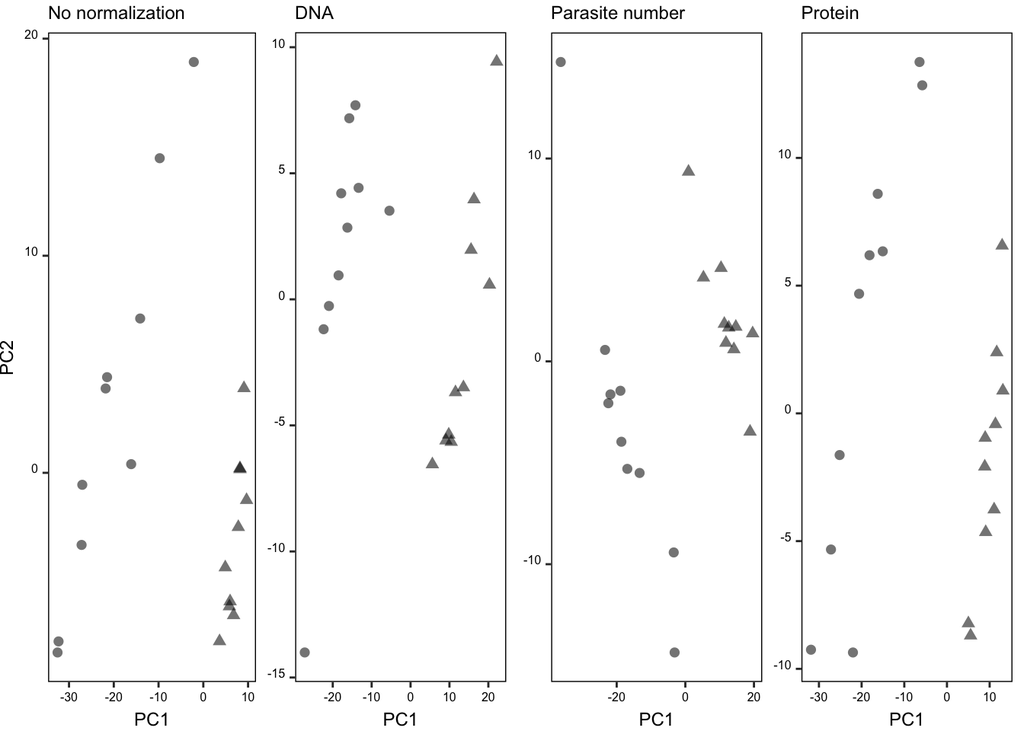

```r
data_plot = data.frame(pca_pro$x[,c(1,2)])
pro = qplot(x = PC1, y = PC2, data = data_plot, shape = factor(labels1), size=I(2), show.legend = F,  alpha = .9 ) +
  custom_theme_pca + scale_shape_manual(values = c(16,17))+
  theme(plot.margin = unit(c(1,2,1,1),"mm")) +
  ggtitle("Protein") +  xlab("PC1") +ylab(NULL)

audrey = qplot(x = PC1, y = PC2, data = data_plot, shape = factor(labels1),color = factor(labels1), size=I(2), show.legend = F,  alpha = .9 ) +
  custom_theme_pca + scale_shape_manual(values = c(16,17))+
  theme(plot.margin = unit(c(1,2,1,1),"mm")) +
  ggtitle("Protein") +  xlab("PC1") +ylab(NULL)

setwd(paste(base_directory,'/figures',sep=""))
ggsave('fig_2d_pro_norm_aug2017.pdf', pro, width = 42, height = 42, units = "mm")
# setwd(paste(base_directory,'/figures',sep=""))
# ggsave('audrey_pro_norm_sept2017.pdf', audrey, width = 42, height = 42, units = "mm")

rotation_a = pca_pro$rotation #loadings
# PC 1 loadings (most important variable in PC1 in full dataset without normalization)
t$PC1_pro = names(tail(sort(abs(rotation_a[,1])),10))
# PC 2 loadings (most important variable in PC2 in full dataset without normalization)
t$PC2_pro = names(tail(sort(abs(rotation_a[,2])),10))

rm(rotation_a,data_plot,pca_pro)

# save plot
setwd(paste(base_directory,'/figures',sep=""))
print(multiplot(unscaled,dna,para,pro,cols = 4))
```

```r
tiff(filename = "test_pca_multi_panel_aug2017.tiff", width = 180, height = 45,
     units = "mm", , res = 300)
multiplot(unscaled,dna,para,pro,cols = 4)
dev.off()
```

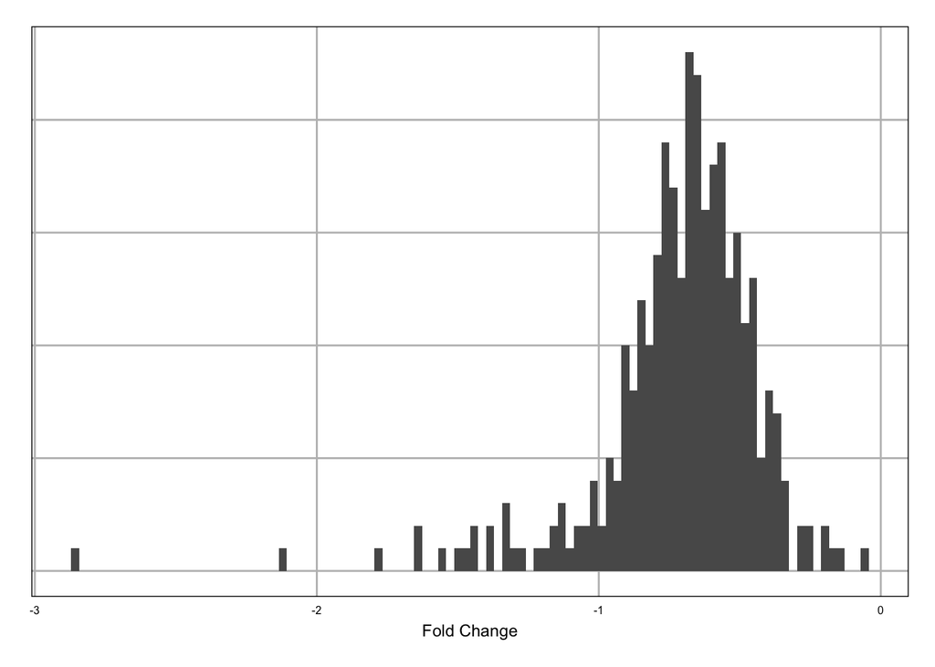

```r
# save loadings
setwd(paste(base_directory,'/figures',sep=""))
write.table(as.data.frame(t), "PC_list_aug2017.csv", sep = ',',col.names = T, row.names = F)
rm(unscaled,dna,para,pro,t)

# calc avg scaled values within experimental conditions/replicates G1 v G2 USING PARA NUMBER NORM
data = t(data_for_pca_para) # metabolites as rows again

# calculate SD and mean
j = nrow(data)
data2 = as.data.frame(rbind(data,c(rep(-10,10),rep(10,10)))) # groups
j = nrow(data2); data2 = make_numeric(data2)
data3 = mutate(data2, met = rownames(data2),
               met_sd_group1 = apply(data2[,data2[j,] == 10], 1, sd), # SD
               met_mean_group1 = rM(data2[,data2[j,] == 10]),
               met_sd_group2 = apply(data2[,data2[j,] == -10], 1, sd ), # SD
               met_mean_group2 = rM(data2[,data2[j,] == -10]))

# calc FC and signficance
fc_data = mutate(data3,fc = met_mean_group1/met_mean_group2)
j = nrow(fc_data); fc_data$pval[j] = NA
for (i in 1:(j-1)) {
  group1 = fc_data[i,which(fc_data[j,] == 10)]; group1$met_mean_group1 = NULL
  group2 = fc_data[i,which(fc_data[j,] == -10)]; group2$met_mean_group2 = NULL
  i_result = t.test(group1,group2, alternative="two.sided", var.equal=F)  #welch's t-test
  fc_data$pval[i] = i_result$p.value }

# Multiple testing correction
fc_data = mutate(fc_data, adj_pval = p.adjust(fc_data$pval, method = "fdr"))

# significant comparisons
significant = subset(fc_data, fc_data$adj_pval <0.05)

setwd(paste(base_directory,'/figures',sep=""))
write.table(significant,"fc_G1_v_G2_aug2017_log.csv",sep = ',',col.names = T,row.names = T)

hi = ggplot(data = significant) + geom_histogram(aes(significant$fc), bins = 100) +
  #geom_vline(xintercept = 2, color = "red", size = 2) +
  custom_theme2 + xlab("Fold Change") + ylab(NULL)
hi
```

```r
setwd(paste(base_directory,'/figures',sep=""))
ggsave('distribution_FC_aug2017.pdf',hi,width = 3,height = 3)

rm(significant,hi,i,i_result,j,data,data2,data3,group1,group2,fc_data)
```

Comparison 2: Process blood batch data

```r
# data_for_pca_dna_comp2
setwd(base_directory)
blood_batch = read.table("blood_batch_data.csv",sep = ',', header = T)
blood_batch = blood_batch[-c(1:15),]; rownames(blood_batch) = NULL
blood_batch$GROUP_NUMBER = sapply(blood_batch$GROUP_NUMBER, function(x) {gsub("(-)", "_minus", x,fixed = TRUE)})
blood_batch$GROUP_NUMBER = sapply(blood_batch$GROUP_NUMBER, function(x) {gsub("(+)", "_plus", x,fixed = TRUE)})
blood_batch$GROUP_NUMBER = sapply(blood_batch$GROUP_NUMBER, function(x) {gsub("-", "_", x,fixed = TRUE)})
blood_batch$GROUP_NUMBER = sapply(blood_batch$GROUP_NUMBER, function(x) {gsub(" ", "", x,fixed = TRUE)})

rownames(blood_batch) = blood_batch$GROUP_NUMBER
data = as.data.frame(merge(blood_batch, data_for_pca_dna_comp2, by = 'row.names'))
rownames(data) = data$Row.names;  data = data[,-c(1:3,5)]; colnames(data)[1] = 'blood'

use_for_pca = make_numeric(as.data.frame(data))
use_for_pca$blood = as.factor(as.character(use_for_pca$blood))

rm(blood_batch,data,data_for_pca_dna_comp2)
```

PCA blood batch

```r
# prep labels
labels_unique = rownames(use_for_pca); substring(labels_unique, 5, 5) = "_"
labels_blood_batch = use_for_pca$blood

labels_drug = lapply(rownames(use_for_pca),
                    function(x) {substr(x,nchar(x)-4,nchar(x))})
labels_drug = unlist(labels_drug)
labels_drug = ifelse(labels_drug == '_plus','plus','minus')

# pca
pca_dna <- prcomp(use_for_pca[,-c(1)], center = F, scale. = F)
summary(pca_dna)
```

```
## Importance of components:
##                            PC1    PC2     PC3     PC4     PC5     PC6
## Standard deviation     11.2139 6.7805 4.78252 4.48862 3.65942 3.39822
## Proportion of Variance  0.4133 0.1511 0.07517 0.06621 0.04401 0.03795
## Cumulative Proportion   0.4133 0.5644 0.63954 0.70575 0.74976 0.78771
##                            PC7     PC8     PC9    PC10   PC11    PC12
## Standard deviation     3.10297 2.84227 2.62945 2.50628 2.3469 2.18194
## Proportion of Variance 0.03164 0.02655 0.02272 0.02064 0.0181 0.01565
## Cumulative Proportion  0.81936 0.84591 0.86863 0.88927 0.9074 0.92302
##                           PC13    PC14    PC15    PC16    PC17    PC18
## Standard deviation     2.04283 1.91411 1.82423 1.73883 1.62027 1.55429
## Proportion of Variance 0.01371 0.01204 0.01094 0.00994 0.00863 0.00794
## Cumulative Proportion  0.93674 0.94878 0.95971 0.96965 0.97828 0.98622
##                           PC19   PC20
## Standard deviation     1.49891 1.3953
## Proportion of Variance 0.00738 0.0064
## Cumulative Proportion  0.99360 1.0000
```

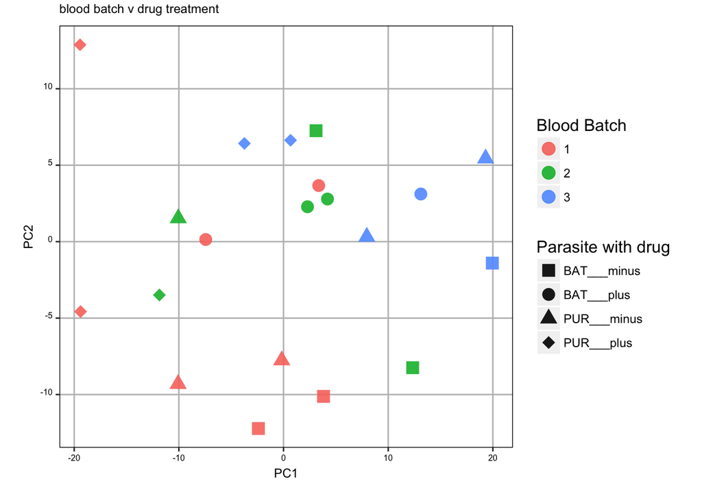

```r
data_plot = data.frame(pca_dna$x[,c(1:4)])
extra = ggplot(data_plot, aes(x = PC1, y = PC2)) +
  geom_point(aes(color = factor(labels_blood_batch),
                 shape = factor(labels_unique)),
             size=I(4), alpha = .9) +
  custom_theme3 +
  scale_shape_manual(values = c(15:18)) +
  theme(plot.margin = unit(c(1,6,6,6),"mm"), # top, right, bottom, and left
        legend.title = element_text(size = 12)) +
  guides(color = guide_legend(title = 'Blood Batch'),
         shape = guide_legend(title = 'Parasite with drug')) +
  ggtitle("blood batch v drug treatment") + ylab("PC2") + xlab("PC1")
extra
```

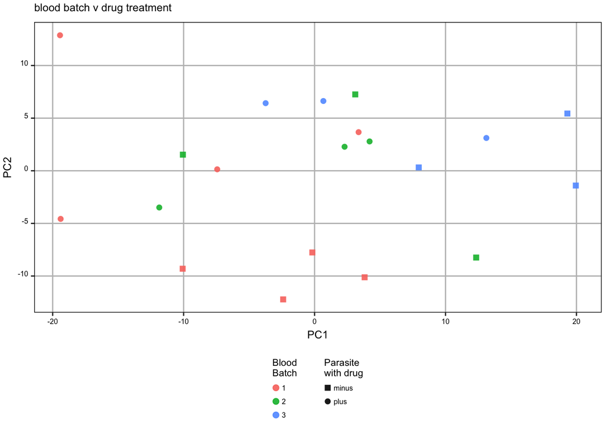

```r
fig_for_viewing = ggplot(data_plot, aes(x = PC1, y = PC2)) +
  geom_point(aes(color = factor(labels_blood_batch),
             shape = factor(labels_drug)),
             size=I(2), alpha = .9) +
  scale_shape_manual(values = c(15:16)) +
  custom_theme3 + theme( plot.margin = unit(c(1,1,1,1),"mm"),
                        legend.title=element_text(size = 8),
                        legend.text=element_text(size = 6),
                        legend.key = element_rect(fill = NA),
                        legend.key.height = unit(4, "mm"),
                        legend.key.width = unit(2, "mm"),
                        legend.position = "bottom",
                        legend.direction = 'vertical') +
  guides(color = guide_legend(title = 'Blood\nBatch'),
         shape = guide_legend(title = 'Parasite\nwith drug')) +
  ggtitle("blood batch v drug treatment") +
  ylab("PC2") + xlab("PC1")
fig_for_viewing
```

```r
fig = ggplot(data_plot, aes(x = PC1, y = PC2)) +
  geom_point(aes(color = factor(labels_blood_batch),
             shape = factor(labels_drug)),
             size=I(2), alpha = .9) +
  scale_shape_manual(values = c(15:16)) +
  custom_theme3 + theme( plot.margin = unit(c(1,1,1,1),"mm")) +
  guides(color = FALSE,shape = FALSE) +
  ylab("PC2") + xlab("PC1")

setwd(paste(base_directory,'/figures',sep=""))
ggsave('blood_batch_drug_pca_aug2017.pdf', fig, width = 60, height = 58, units = "mm")

rm(extra, fig, fig_for_viewing,labels_unique,labels_drug,labels_blood_batch,data_plot,pca_dna)
```

Predict blood batch con’t (hide warnings here)

```r
comparison_2_df = remove_characters_from_colnames(use_for_pca)
which(duplicated(colnames(comparison_2_df)))
```

```
## integer(0)
```

FC, if you aren’t getting sig hits here, classification based methods will not reveal anything unless sample size is large enough for non linear effects to emerge.

Calculate Drug/NoDrug FC for comparison 2

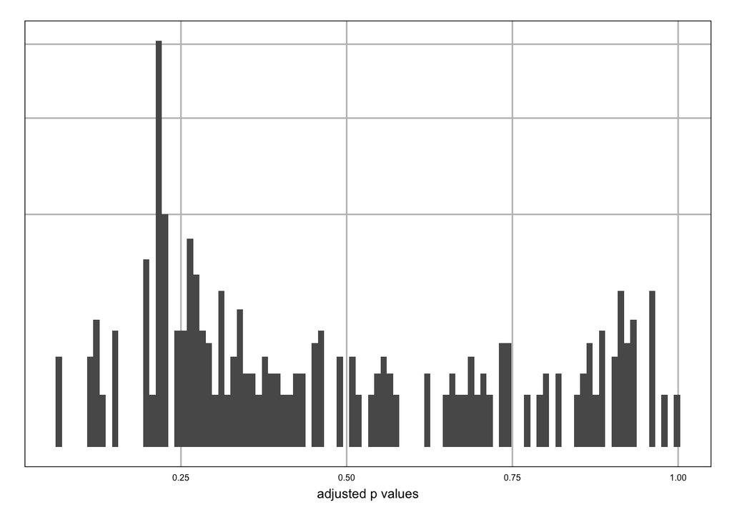

```r
df = comparison_2_df
df$blood = NULL
df = mutate(df,sample = rownames(df),
            drug = substr(rownames(df),nchar(rownames(df))-3, nchar(rownames(df))))
df$drug = ifelse(df$drug == 'inus',-10,10)
rownames(df) = df$sample; df$sample = NULL
scaled = make_numeric(as.data.frame(t(df)))

# calculate SD and mean
j = nrow(scaled)
scaled2 = mutate(scaled,
                 met = rownames(scaled),
                 met_sd_group1 = apply(scaled[,scaled[j,] == 10], 1, sd), # SD
                 met_mean_group1 = rM(scaled[,scaled[j,] == 10]), # MU
                 met_sd_group2 = apply(scaled[,scaled[j,] == -10], 1, sd ), # SD
                 met_mean_group2 = rM(scaled[,scaled[j,] == -10]))

fc_data = mutate(scaled2,fc = met_mean_group1/met_mean_group2)

j = nrow(fc_data); fc_data$pval[j] = NA
for (i in 1:(j-1)) {
  group1 = fc_data[i,which(fc_data[j,] == 10)]; group1$met_mean_group1 = NULL
  group2 = fc_data[i,which(fc_data[j,] == -10)]; group2$met_mean_group23 = NULL
  i_result = t.test(group1,group2, alternative="two.sided", var.equal=F)  #welch's t-test
  fc_data$pval[i] = i_result$p.value }

# Multiple testing correction
fc_data = mutate(fc_data, adj_pval = p.adjust(fc_data$pval, method = "fdr"))

hi = ggplot(data = fc_data[-j,]) + geom_histogram(aes(fc_data$adj_pval[-j]), bins = 100) +
  custom_theme2 + scale_y_sqrt() +
  xlab("adjusted p values") + ylab('count (sqrt)')
hi
```

```r
significant = subset(fc_data, adj_pval < 0.05) # NOTHING SIGNFICANT WHEN COMPARING DRUG TREATED TO UNTREATED
dim(significant)
```

```
## [1]  0 28
```

```r
rm(significant,i,j,df, group1,group2,fc_data,hi,scaled)
```

Distance heatmap in Aug 9 version

Calculate Blood batch FC

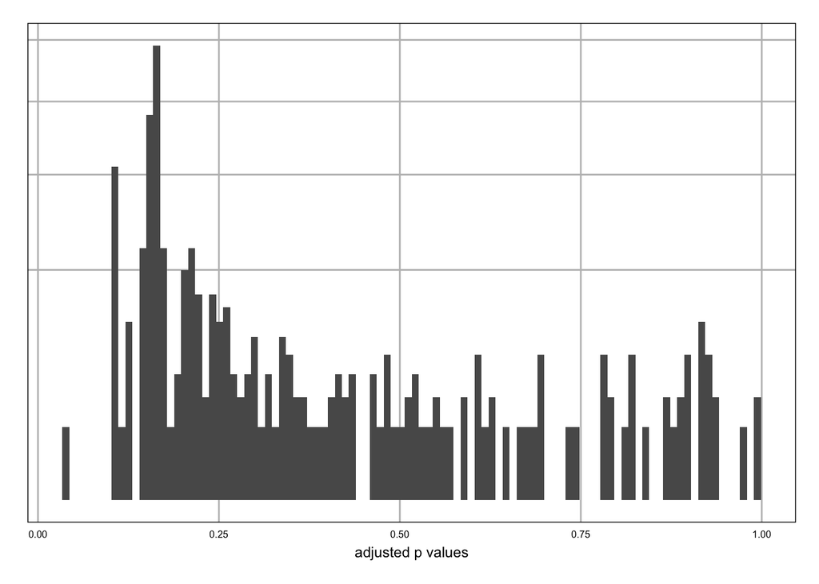

```r
# only trying to predict blood batch 1
df = make_numeric(comparison_2_df)

df$blood[df$blood == '2'] = '23'
df$blood[df$blood == '3'] = '23'
scaled = make_numeric(as.data.frame(t(df)))

# calculate SD and mean
scaled = mutate(scaled,
                met = rownames(scaled),
                met_sd_group1 = apply(scaled[,scaled[1,] == 1], 1, sd), # SD
                met_mean_group1 = rM(scaled[,scaled[1,] == 1]), # MU
                met_sd_group23 = apply(scaled[,scaled[1,] == 23], 1, sd ), # SD
                met_mean_group23 = rM(scaled[,scaled[1,] == 23]))

fc_data = mutate(scaled,fc = met_mean_group1/met_mean_group23)

fc_data$pval[1] = NA
for (i in 2:nrow(fc_data)) {
  group1 = fc_data[i,which(fc_data[1,] == 1)]; group1$met_mean_group1 = NULL
  group1$met_sd_group1 = NULL
  group2 = fc_data[i,which(fc_data[1,] == 23)]; group2$met_mean_group23 = NULL
  group2$met_sd_group23 = NULL
  i_result = t.test(group1,group2,
                    alternative="two.sided", var.equal=F)  #welch's t-test
  fc_data$pval[i] = i_result$p.value }

# Multiple testing correction
fc_data = mutate(fc_data, adj_pval = p.adjust(fc_data$pval, method = "fdr"))

plot_fc = fc_data[-c(1),]
hi = ggplot(data = plot_fc) + geom_histogram(aes(plot_fc$adj_pval), bins = 100) +
  custom_theme2 + scale_y_sqrt() +
  xlab("adjusted p values") + ylab('sqrt count')
hi
```

```r
significant = subset(fc_data, adj_pval < 0.05) # 1 met SIGNFICANT
significant
```

```
##    BAT_A_minus  BAT_A_plus BAT_B_minus BAT_B_plus BAT_C_minus BAT_C_plus
## 22   0.6559383 -0.01729655   0.7540786  0.9808475   -1.066714  -0.841268
##    BAT_D_minus BAT_D_plus BAT_E_minus BAT_E_plus PUR_A_minus PUR_A_plus
## 22   -1.405726  -1.279508   -2.065405 -0.6260494   0.7549689   1.048581
##    PUR_B_minus PUR_B_plus PUR_C_minus PUR_C_plus PUR_D_minus PUR_D_plus
## 22  0.09527597   1.647472   -0.656282  0.8031075   -1.195266  0.3645349
##    PUR_E_minus PUR_E_plus                              met met_sd_group1
## 22  -0.4456656 0.01729655 N1arachidonoylGPE204n6_predicted     0.5309548
##    met_mean_group1 met_sd_group23 met_mean_group23        fc         pval
## 22       0.7399833       0.802104       -0.6997454 -1.057504 0.0001344151
##     adj_pval
## 22 0.0399213
```

```r
rm(significant,i,df, group1,group2,fc_data,plot_fc,hi,scaled)
```

Predict blood batch 1 : RF

```r
df = as.data.frame(comparison_2_df)
df = make_numeric(df)
df$blood[df$blood == '2'] = '23'
df$blood[df$blood == '3'] = '23'
df$blood = as.factor(df$blood)

# split into training and validation data set # NOT NEEDED FOR RF, inherent in implementation
varNames = names(df); varNames = varNames[!varNames %in%  c("blood")]
varNames1 = paste(varNames, collapse = "+")
formula = as.formula(paste("blood", varNames1, sep = " ~ "))
set.seed(2017)
rf_blood = randomForest(formula, data = df, ntree=500, na.action = "na.omit", importance=T, classwt = c(.33,.67)) # class imbalance -> increase penalty for less abundant class
# OOB estimate of  error rate: 30%
# Confusion matrix:
#     1 2_3 class.error
# 1   4   4        0.50
# 23 2   10        0.17
return(rf_blood)
```

```
##
## Call:
##  randomForest(formula = formula, data = df, ntree = 500, importance = T,      classwt = c(0.33, 0.67), na.action = "na.omit")
##                Type of random forest: classification
##                      Number of trees: 500
## No. of variables tried at each split: 17
##
##         OOB estimate of  error rate: 30%
## Confusion matrix:
##    1 23 class.error
## 1  4  4   0.5000000
## 23 2 10   0.1666667
```

```r
#varImpPlot(rf_blood, sort = T,main="Variable Importance for RF",n.var=10)
blood_imp = as.data.frame(rf_blood$importance)
blood_imp = blood_imp[order(blood_imp$MeanDecreaseAccuracy),]
blood_imp_rf = blood_imp[,-c(1:2)]
top_blood_imp_rf = blood_imp_rf[(nrow(blood_imp_rf)-10):nrow(blood_imp_rf),]
worst_blood_imp_rf = blood_imp_rf[1:10,]

dim(blood_imp[blood_imp$MeanDecreaseAccuracy>0,])
```

```
## [1] 95  4
```

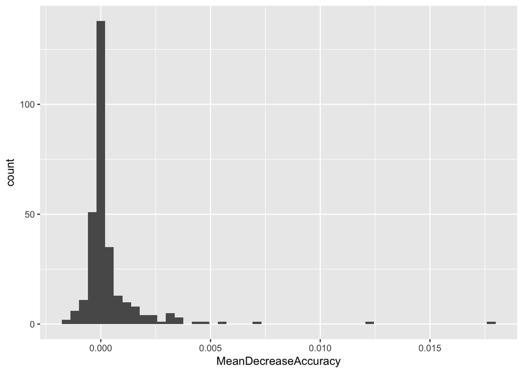

```r
# fancier plotting
ggplot() + geom_histogram(data=blood_imp_rf, aes(x = MeanDecreaseAccuracy), bins = 50)
```

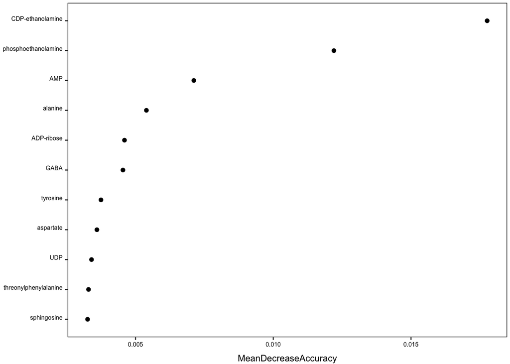

```r
# plot top blood predictors
top_blood_imp_rf = mutate(top_blood_imp_rf, met = rownames(top_blood_imp_rf))

top_blood_imp_rf$met[which(top_blood_imp_rf$met == 'uridine5diphosphateUDP')] = 'UDP'
top_blood_imp_rf$met[which(top_blood_imp_rf$met == 'gammaaminobutyrateGABA')] = 'GABA'
top_blood_imp_rf$met[which(top_blood_imp_rf$met == 'adenosine5diphosphoriboseADPribose')] = 'ADP-ribose'
top_blood_imp_rf$met[which(top_blood_imp_rf$met == 'adenosine5monophosphateAMP')] = 'AMP'
top_blood_imp_rf$met[which(top_blood_imp_rf$met == 'cytidine5diphosphoethanolamine')] = 'CDP-ethanolamine'

ordr = order(top_blood_imp_rf$MeanDecreaseAccuracy)
top_blood_imp_rf$met <- factor(top_blood_imp_rf$met, levels = top_blood_imp_rf$met[ordr])
top = ggplot() + theme( plot.margin = unit(c(1,1,1,1),"mm")) +
  geom_point(data=top_blood_imp_rf, aes(x = MeanDecreaseAccuracy, y = factor(met))) +
  custom_theme_pca + ylab(NULL)
  #ggtitle('metabolites most predictive of blood batch') +
top
```

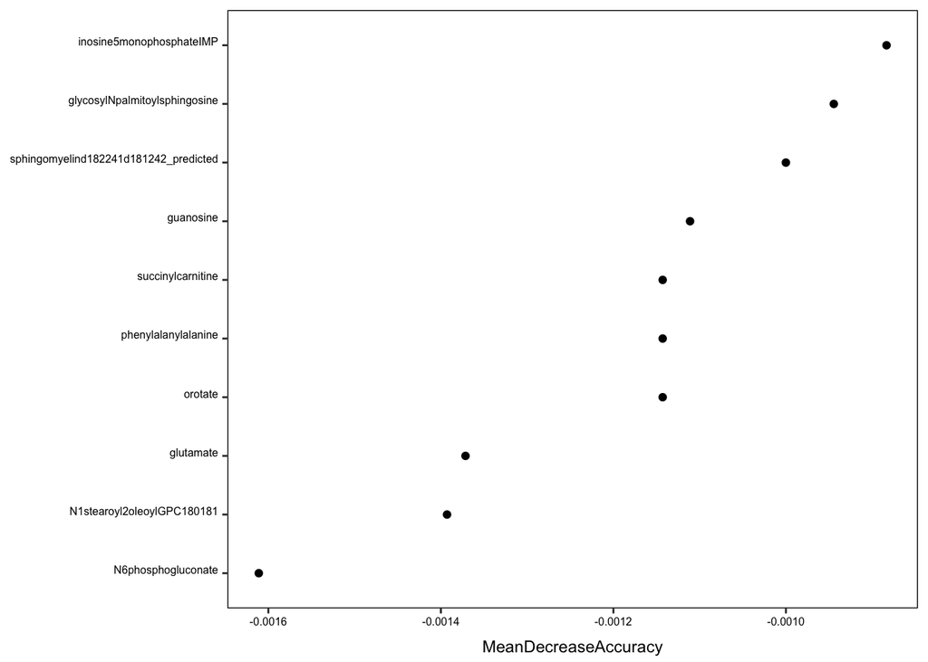

```r
setwd(paste(base_directory,'/figures',sep=""))
ggsave('fig_3part_topBB_mets_aug2017.pdf', top, width = 70, height = 50, units = "mm")

#plot worst blood predictors
worst_blood_imp_rf = mutate(worst_blood_imp_rf, met = rownames(worst_blood_imp_rf))
ordr = order(worst_blood_imp_rf$MeanDecreaseAccuracy)
worst_blood_imp_rf$met <- factor(worst_blood_imp_rf$met, levels = worst_blood_imp_rf$met[ordr])
worst = ggplot() +
  geom_point(data=worst_blood_imp_rf, aes(x = MeanDecreaseAccuracy, y = factor(met))) +
  custom_theme_pca + ylab(NULL)
  #ggtitle('metabolites least predictive of blood batch') +
worst
```

```r
setwd(paste(base_directory,'/figures',sep=""))
ggsave('fig_3part_worstBB_mets_aug2017.pdf', worst, width = 80, height = 60, units = "mm")

rm(worst_blood_imp_rf,top_blood_imp_rf,ordr,blood_imp,blood_imp_rf,rf_blood,df,top,worst)
```

Predict sample group : RF

```r
df = as.data.frame(comparison_2_df)
df = mutate(df, sample = rownames(df), drug = substr(sample, nchar(sample)-4, nchar(sample)))
rownames(df) = df$sample
df$drug = as.factor(df$drug)
df$sample = NULL; df$blood = NULL
df[,-c(ncol(df))] = make_numeric(df[,-c(ncol(df))])

# split into training and validation data set # NOT NEEDED FOR RF, inherent in implementation
varNames = names(df); varNames = varNames[!varNames %in%  c("drug")]
varNames1 = paste(varNames, collapse = "+")
formula = as.formula(paste("drug", varNames1, sep = " ~ "))
set.seed(2017)
rf_Drug = randomForest(formula, data = df, ntree=500, na.action = "na.omit", importance=T)
# OOB estimate of  error rate: 30%
# Confusion matrix:
#       _plus minus class.error
# _plus     7     3         0.3
# minus     3     7         0.3
return(rf_Drug)
```

```
##
## Call:
##  randomForest(formula = formula, data = df, ntree = 500, importance = T,      na.action = "na.omit")
##                Type of random forest: classification
##                      Number of trees: 500
## No. of variables tried at each split: 17
##
##         OOB estimate of  error rate: 30%
## Confusion matrix:
##       _plus minus class.error
## _plus     7     3         0.3
## minus     3     7         0.3
```

```r
#varImpPlot(rf_Drug, sort = T,main="Variable Importance for RF",n.var=10)
drug_imp = as.data.frame(rf_Drug$importance)
drug_imp = drug_imp[order(drug_imp$MeanDecreaseAccuracy),]
drug_imp_rf = drug_imp[,-c(1:2)]
top_drug_imp_rf = drug_imp_rf[(nrow(drug_imp_rf)-10):nrow(drug_imp_rf),]
worst_drug_imp_rf = drug_imp_rf[1:10,]

dim(drug_imp[drug_imp$MeanDecreaseAccuracy>0,])
```

```
## [1] 118   4
```

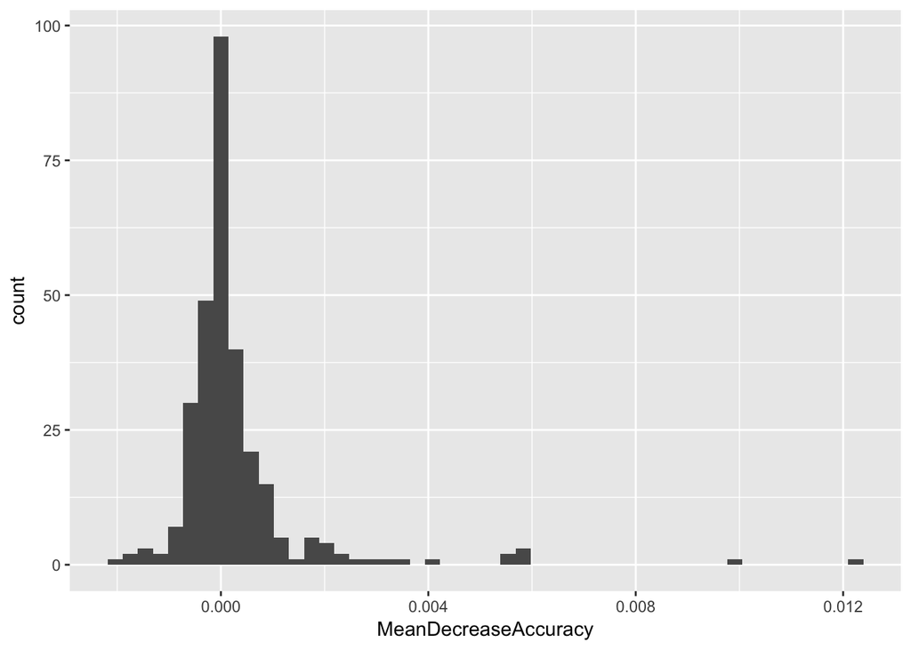

```r
# fancier plotting
ggplot() + geom_histogram(data=drug_imp_rf, aes(x = MeanDecreaseAccuracy), bins = 50)
```

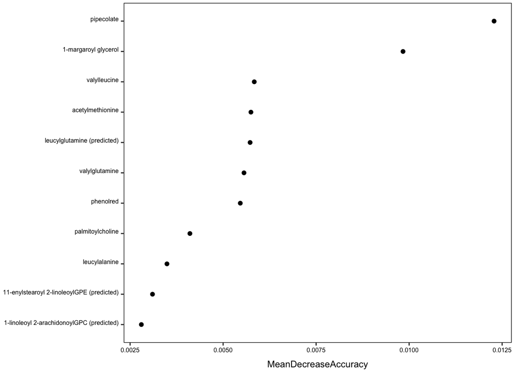

```r
# plot top blood predictors
top_drug_imp_rf = mutate(top_drug_imp_rf, met = rownames(top_drug_imp_rf))

top_drug_imp_rf$met[which(top_drug_imp_rf$met == 'N1linoleoyl2arachidonoylGPC182204n6_predicted')] = '1-linoleoyl 2-arachidonoylGPC (predicted)'
top_drug_imp_rf$met[which(top_drug_imp_rf$met == 'N11enylstearoyl2linoleoylGPEP180182_predicted')] = '11-enylstearoyl 2-linoleoylGPE (predicted)'
top_drug_imp_rf$met[which(top_drug_imp_rf$met == 'leucylglutamine_predicted')] = 'leucylglutamine (predicted)'
top_drug_imp_rf$met[which(top_drug_imp_rf$met == 'Nacetylmethionine')] = 'acetylmethionine'
top_drug_imp_rf$met[which(top_drug_imp_rf$met == 'N1margaroylglycerol170')] = '1-margaroyl glycerol'

ordr = order(top_drug_imp_rf$MeanDecreaseAccuracy)
top_drug_imp_rf$met <- factor(top_drug_imp_rf$met, levels = top_drug_imp_rf$met[ordr])
top = ggplot() + theme( plot.margin = unit(c(1,2.5,1,1),"mm")) +
  geom_point(data=top_drug_imp_rf, aes(x = MeanDecreaseAccuracy, y = factor(met))) +
  custom_theme_pca + ylab(NULL)
  #ggtitle('metabolites most predictive of drug treatment') +
top
```

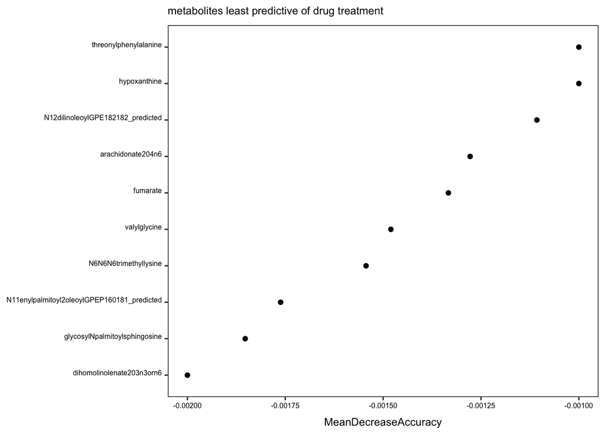

```r
setwd(paste(base_directory,'/figures',sep=""))
ggsave('fig_3part_top_Drug_mets_aug2017.pdf', top, width = 94, height = 50, units = "mm")

#plot worst blood predictors
worst_drug_imp_rf = mutate(worst_drug_imp_rf, met = rownames(worst_drug_imp_rf))
ordr = order(worst_drug_imp_rf$MeanDecreaseAccuracy)
worst_drug_imp_rf$met <- factor(worst_drug_imp_rf$met, levels = worst_drug_imp_rf$met[ordr])
worst = ggplot() +
  geom_point(data=worst_drug_imp_rf, aes(x = MeanDecreaseAccuracy, y = factor(met))) +
  custom_theme_pca +
  ggtitle('metabolites least predictive of drug treatment') + ylab(NULL)
worst
```

```r
setwd(paste(base_directory,'/figures',sep=""))
ggsave('fig_3part_worst_Drug_mets_aug2017.pdf', worst, width = 80, height = 60, units = "mm")
```

```r
setwd(base_directory)
raw_file = read.csv("met_methods_raw_data.txt", sep = "\t", header = T,
                colClasses = c(rep(NA, 14), rep('numeric',35)),
                na.strings=c('',"NA"), stringsAsFactors = F)
raw_file = raw_file[-376,-c(1,5:14)]

raw1 = prep_raw(raw_file)
identifiers = prep_sample_identifiers(raw1)
df = raw1[c(131,204,289),-c(1,2)]
# cholesterol and HEPES are correlated in raw data
cor.test(as.numeric(df[1,]),as.numeric(df[2,]))
```

```
##
##  Pearson's product-moment correlation
##
## data:  as.numeric(df[1, ]) and as.numeric(df[2, ])
## t = 5.6754, df = 33, p-value = 2.512e-06
## alternative hypothesis: true correlation is not equal to 0
## 95 percent confidence interval:
##  0.4825888 0.8394492
## sample estimates:
##       cor
## 0.7028089
```

```r
# cholesterol and phenolred are correlated in raw data
cor.test(as.numeric(df[1,]),as.numeric(df[3,]))
```

```
##
##  Pearson's product-moment correlation
##
## data:  as.numeric(df[1, ]) and as.numeric(df[3, ])
## t = 5.7688, df = 32, p-value = 2.122e-06
## alternative hypothesis: true correlation is not equal to 0
## 95 percent confidence interval:
##  0.4954615 0.8475284
## sample estimates:
##       cor
## 0.7139981
```

```r
# HEPES and phenolred are correlated in raw data
cor.test(as.numeric(df[2,]),as.numeric(df[3,]))
```

```
##
##  Pearson's product-moment correlation
##
## data:  as.numeric(df[2, ]) and as.numeric(df[3, ])
## t = 23.364, df = 32, p-value < 2.2e-16
## alternative hypothesis: true correlation is not equal to 0
## 95 percent confidence interval:
##  0.9440234 0.9860117
## sample estimates:
##       cor
## 0.9719177
```

```r
colnames(identifiers) = identifiers[3,]

df = (merge(t(identifiers), t(df), by = 'row.names'))
df = as.data.frame(df)

#none
cor.test(as.numeric(df$CLIENT_PROTEIN), as.numeric(df$cholesterol))
```

```
##
##  Pearson's product-moment correlation
##
## data:  as.numeric(df$CLIENT_PROTEIN) and as.numeric(df$cholesterol)
## t = 0.55199, df = 33, p-value = 0.5847
## alternative hypothesis: true correlation is not equal to 0
## 95 percent confidence interval:
##  -0.2454200  0.4156471
## sample estimates:
##        cor
## 0.09564926
```

```r
#none
cor.test(as.numeric(df$TOTAL_PARASITES), as.numeric(df$cholesterol))
```

```
##
##  Pearson's product-moment correlation
##
## data:  as.numeric(df$TOTAL_PARASITES) and as.numeric(df$cholesterol)
## t = 0.073117, df = 33, p-value = 0.9422
## alternative hypothesis: true correlation is not equal to 0
## 95 percent confidence interval:
##  -0.3218847  0.3445124
## sample estimates:
##        cor
## 0.01272703
```

```r
# minimally correlated
cor.test(as.numeric(df$DSDNA_ASSAY), as.numeric(df$cholesterol))
```

```
##
##  Pearson's product-moment correlation
##
## data:  as.numeric(df$DSDNA_ASSAY) and as.numeric(df$cholesterol)
## t = 3.9939, df = 33, p-value = 0.0003423
## alternative hypothesis: true correlation is not equal to 0
## 95 percent confidence interval:
##  0.2934110 0.7595905
## sample estimates:
##       cor
## 0.5708416
```

```r
#none
cor.test(as.numeric(df$CLIENT_PROTEIN), as.numeric(df$phenolred))
```

```
##
##  Pearson's product-moment correlation
##
## data:  as.numeric(df$CLIENT_PROTEIN) and as.numeric(df$phenolred)
## t = 1.1811, df = 32, p-value = 0.2463
## alternative hypothesis: true correlation is not equal to 0
## 95 percent confidence interval:
##  -0.1437160  0.5074742
## sample estimates:
##       cor
## 0.2043826
```

```r
#none
cor.test(as.numeric(df$TOTAL_PARASITES), as.numeric(df$phenolred))
```

```
##
##  Pearson's product-moment correlation
##
## data:  as.numeric(df$TOTAL_PARASITES) and as.numeric(df$phenolred)
## t = -0.018104, df = 32, p-value = 0.9857
## alternative hypothesis: true correlation is not equal to 0
## 95 percent confidence interval:
##  -0.3409969  0.3353283
## sample estimates:
##          cor
## -0.003200269
```

```r
# correlated
cor.test(as.numeric(df$DSDNA_ASSAY), as.numeric(df$phenolred))
```

```
##
##  Pearson's product-moment correlation
##
## data:  as.numeric(df$DSDNA_ASSAY) and as.numeric(df$phenolred)
## t = 7.2203, df = 32, p-value = 3.352e-08
## alternative hypothesis: true correlation is not equal to 0
## 95 percent confidence interval:
##  0.6118991 0.8887597
## sample estimates:
##       cor
## 0.7871791
```

```r
#none
cor.test(as.numeric(df$CLIENT_PROTEIN), as.numeric(df$HEPES))
```

```
##
##  Pearson's product-moment correlation
##
## data:  as.numeric(df$CLIENT_PROTEIN) and as.numeric(df$HEPES)
## t = 1.3311, df = 33, p-value = 0.1923
## alternative hypothesis: true correlation is not equal to 0
## 95 percent confidence interval:
##  -0.1162621  0.5198701
## sample estimates:
##       cor
## 0.2257301
```

```r
#none
cor.test(as.numeric(df$TOTAL_PARASITES), as.numeric(df$HEPES))
```

```
##
##  Pearson's product-moment correlation
##
## data:  as.numeric(df$TOTAL_PARASITES) and as.numeric(df$HEPES)
## t = 0.39871, df = 33, p-value = 0.6927
## alternative hypothesis: true correlation is not equal to 0
## 95 percent confidence interval:
##  -0.2702426  0.3934086
## sample estimates:
##        cor
## 0.06923952
```

```r
# correlated
cor.test(as.numeric(df$DSDNA_ASSAY), as.numeric(df$HEPES))
```

```
##
##  Pearson's product-moment correlation
##
## data:  as.numeric(df$DSDNA_ASSAY) and as.numeric(df$HEPES)
## t = 9.1215, df = 33, p-value = 1.537e-10
## alternative hypothesis: true correlation is not equal to 0
## 95 percent confidence interval:
##  0.7143702 0.9199965
## sample estimates:
##       cor
## 0.8461751
```

```r
df = t(data_for_pca_unnorm[,c(131,204,289)])
# cholesterol and HEPES are not correlated in unnormalized data
cor.test(as.numeric(df[1,]),as.numeric(df[2,]))
```

```
##
##  Pearson's product-moment correlation
##
## data:  as.numeric(df[1, ]) and as.numeric(df[2, ])
## t = 0.87208, df = 18, p-value = 0.3947
## alternative hypothesis: true correlation is not equal to 0
## 95 percent confidence interval:
##  -0.2647702  0.5911883
## sample estimates:
##       cor
## 0.2013409
```

```r
# cholesterol and phenolred are not correlated in unnormalized data
cor.test(as.numeric(df[1,]),as.numeric(df[3,]))
```

```
##
##  Pearson's product-moment correlation
##
## data:  as.numeric(df[1, ]) and as.numeric(df[3, ])
## t = 0.077773, df = 18, p-value = 0.9389
## alternative hypothesis: true correlation is not equal to 0
## 95 percent confidence interval:
##  -0.4276612  0.4571412
## sample estimates:
##        cor
## 0.01832814
```

```r
# HEPES and phenolred ARE correlated in unnormalized data
cor.test(as.numeric(df[2,]),as.numeric(df[3,]))
```

```
##
##  Pearson's product-moment correlation
##
## data:  as.numeric(df[2, ]) and as.numeric(df[3, ])
## t = 15.847, df = 18, p-value = 5.125e-12
## alternative hypothesis: true correlation is not equal to 0
## 95 percent confidence interval:
##  0.9142833 0.9867136
## sample estimates:
##       cor
## 0.9659792
```

```r
df = t(data_for_pca_dna[,c(131,204,289)])
# cholesterol and HEPES are correlated in dna_norm data
cor.test(as.numeric(df[1,]),as.numeric(df[2,]))
```

```
##
##  Pearson's product-moment correlation
##
## data:  as.numeric(df[1, ]) and as.numeric(df[2, ])
## t = 8.2189, df = 18, p-value = 1.665e-07
## alternative hypothesis: true correlation is not equal to 0
## 95 percent confidence interval:
##  0.7351456 0.9554216
## sample estimates:
##       cor
## 0.8885921
```

```r
# cholesterol and phenolred are anti correlated in dna_norm data
cor.test(as.numeric(df[1,]),as.numeric(df[3,]))
```

```
##
##  Pearson's product-moment correlation
##
## data:  as.numeric(df[1, ]) and as.numeric(df[3, ])
## t = -6.1945, df = 18, p-value = 7.586e-06
## alternative hypothesis: true correlation is not equal to 0
## 95 percent confidence interval:
##  -0.9285492 -0.6024824
## sample estimates:
##        cor
## -0.8250388
```

```r
# HEPES and phenolred ARE anti correlated in dna_norm data
cor.test(as.numeric(df[2,]),as.numeric(df[3,]))
```

```
##
##  Pearson's product-moment correlation
##
## data:  as.numeric(df[2, ]) and as.numeric(df[3, ])
## t = -2.879, df = 18, p-value = 0.009988
## alternative hypothesis: true correlation is not equal to 0
## 95 percent confidence interval:
##  -0.8042038 -0.1583346
## sample estimates:
##        cor
## -0.5615123
```

```r
df = t(data_for_pca_pro[,c(131,204,289)])
# cholesterol and HEPES are not correlated in pro_norm data
cor.test(as.numeric(df[1,]),as.numeric(df[2,]))
```

```
##
##  Pearson's product-moment correlation
##
## data:  as.numeric(df[1, ]) and as.numeric(df[2, ])
## t = 1.158, df = 18, p-value = 0.262
## alternative hypothesis: true correlation is not equal to 0
## 95 percent confidence interval:
##  -0.2028443  0.6321716
## sample estimates:
##       cor
## 0.2633121
```

```r
# cholesterol and phenolred are not correlated in pro_norm data
cor.test(as.numeric(df[1,]),as.numeric(df[3,]))
```

```
##
##  Pearson's product-moment correlation
##
## data:  as.numeric(df[1, ]) and as.numeric(df[3, ])
## t = 0.31947, df = 18, p-value = 0.7531
## alternative hypothesis: true correlation is not equal to 0
## 95 percent confidence interval:
##  -0.3800626  0.5009618
## sample estimates:
##        cor
## 0.07508663
```

```r
# HEPES and phenolred ARE correlated in pro_norm data
cor.test(as.numeric(df[2,]),as.numeric(df[3,]))
```

```
##
##  Pearson's product-moment correlation
##
## data:  as.numeric(df[2, ]) and as.numeric(df[3, ])
## t = 15.567, df = 18, p-value = 6.915e-12
## alternative hypothesis: true correlation is not equal to 0
## 95 percent confidence interval:
##  0.9114196 0.9862523
## sample estimates:
##       cor
## 0.9648108
```

```r
df = t(data_for_pca_para[,c(131,204,289)])
# cholesterol and HEPES are correlated in para_norm data
cor.test(as.numeric(df[1,]),as.numeric(df[2,]))
```

```
##
##  Pearson's product-moment correlation
##
## data:  as.numeric(df[1, ]) and as.numeric(df[2, ])
## t = 9.1728, df = 18, p-value = 3.315e-08
## alternative hypothesis: true correlation is not equal to 0
## 95 percent confidence interval:
##  0.7772866 0.9632566
## sample estimates:
##       cor
## 0.9076181
```

```r
# cholesterol and phenolred are anti correlated in pro_norm data
cor.test(as.numeric(df[1,]),as.numeric(df[3,]))
```

```
##
##  Pearson's product-moment correlation
##
## data:  as.numeric(df[1, ]) and as.numeric(df[3, ])
## t = -3.2109, df = 18, p-value = 0.004845
## alternative hypothesis: true correlation is not equal to 0
## 95 percent confidence interval:
##  -0.8255359 -0.2195972
## sample estimates:
##        cor
## -0.6034745
```

```r
# HEPES and phenolred are not correlated in pro_norm data
cor.test(as.numeric(df[2,]),as.numeric(df[3,]))
```

```
##
##  Pearson's product-moment correlation
##
## data:  as.numeric(df[2, ]) and as.numeric(df[3, ])
## t = -1.2093, df = 18, p-value = 0.2422
## alternative hypothesis: true correlation is not equal to 0
## 95 percent confidence interval:
##  -0.6391151  0.1916464
## sample estimates:
##       cor
## -0.274122
```